# Shiny

Dayu Tie

2024-11-12

```r
library(shiny)
#install.packages('shinydashboard')
```

Hadley_1

```r
ui <- fluidPage(
  selectInput("dataset", label = "Dataset", choices = ls("package:datasets")),
  verbatimTextOutput("summary"),
  tableOutput("table")
)


server <- function(input, output, session) {
  output$summary <- renderPrint({
    dataset <- get(input$dataset, "package:datasets")
    summary(dataset)
  })

  output$table <- renderTable({
    dataset <- get(input$dataset, "package:datasets")
    dataset
  })
}

shinyApp(ui, server)
```

```
##
## Listening on http://127.0.0.1:5802
```

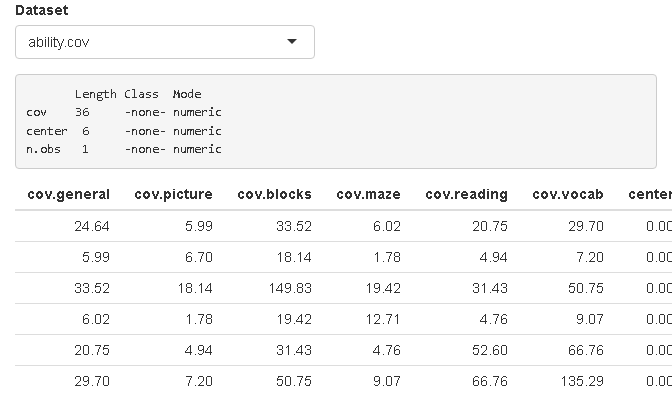

Hadley_2

```r
ui <- fluidPage(
  selectInput("dataset", label = "Dataset", choices = ls("package:datasets")),
  verbatimTextOutput("summary"),
  tableOutput("table")
)

server <- function(input, output, session) {
  # Create a reactive expression
  dataset <- reactive({
    get(input$dataset, "package:datasets")
  })

  output$summary <- renderPrint({
    # Use a reactive expression by calling it like a function
    summary(dataset())
  })

  output$table <- renderTable({
    dataset()
  })
}
shinyApp(ui, server)
```

```
##
## Listening on http://127.0.0.1:8738
```

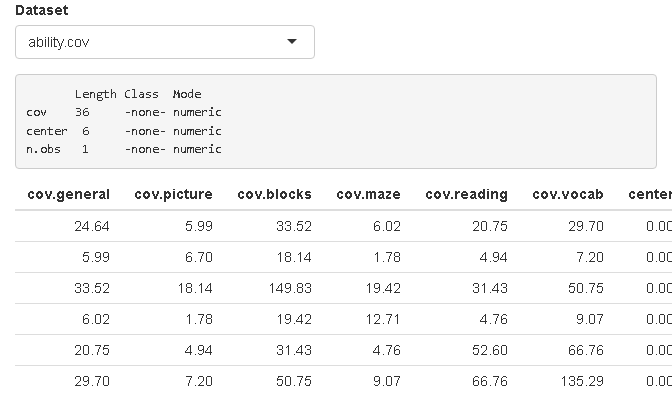

#Hadley_1 demonstrates the basic functionality with duplicated dataset retrieval, #while Hadley_2 showcases the use of reactive programming to optimize the app by eliminating redundancy.

2.3.5

1.Which of and should each of the following render functions be paired with?textOutput()verbatimTextOutput()

A.renderPrint(summary(mtcars))

B.renderText(“Good morning!”)

C.renderPrint(t.test(1:5, 2:6))

D.renderText(str(lm(mpg ~ wt, data = mtcars)))

A：verbatimTextOutput() B：textOutput() C：verbatimTextOutput() D：textOutput()

```r
#install.packages('shiny')
library('shiny')
```

```
##
## Listening on http://127.0.0.1:7103
```

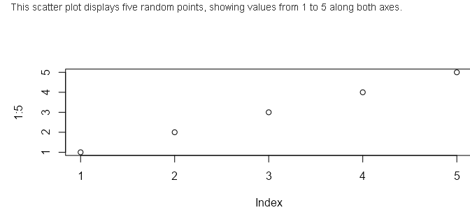

```r
library(shiny)

ui <- fluidPage(
  textOutput("plot_description"),
  plotOutput("plot", height = "300px", width = "700px")
)

server <- function(input, output, session) {
  output$plot <- renderPlot(
    plot(1:5), res = 96)

  output$plot_description <- renderText({
    "This scatter plot displays five random points, showing values from 1 to 5 along both axes."
  })
}

shinyApp(ui, server)
```

```r
ui <- fluidPage(
  dataTableOutput("table")
)
```

[output not shown]

```r
server <- function(input, output, session) {
  output$table <- DT::renderDT(mtcars, options = list(pageLength = 5))
}

shinyApp(ui, server)
```

```
##
## Listening on http://127.0.0.1:4790
```

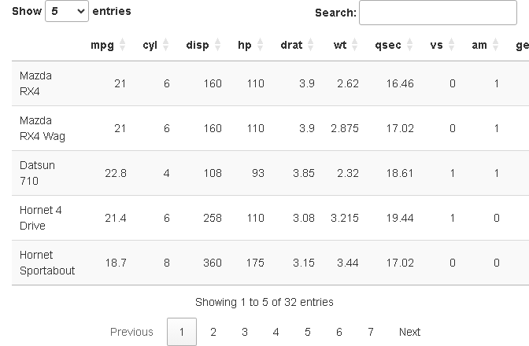

3.3.6 1.

```r
ui <- fluidPage(
  textInput("name", "What's your name?"),
  textOutput("greeting")
)
```

```r
server1 <- function(input, output, session) {
  output$greeting <- renderText({
    paste0("Hello ", input$name)
  })
}
server2 <- function(input, output, session) {
  output$greeting <- renderText({
    paste0("Hello ", input$name)
  })
}
server3 <- function(input, output, session) {
  output$greeting <- renderText({
    paste0("Hello ", input$name)
  })
}
shinyApp(ui, server)
```

```
##
## Listening on http://127.0.0.1:3632
```

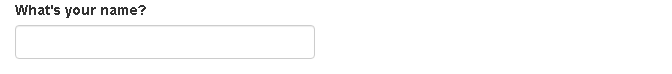

2. reactive graph1

input$a input$b | | V V reactive(c) (c <- input$a + input$b) | V input$d reactive(e) (e <- c() + input$d) | | V V output$f (renderText(e()))

reactive graph2

input$x1 input$x2 input$x3 | | | V V V reactive(x) (x <- input$x1 + input$x2 + input$x3)

input$y1 input$y2 | | V V reactive(y) (y <- input$y1 + input$y2) | V output$z (renderText(x() / y()))

reactive graph3 input$a input$b input$c input$d | | | | V V V V reactive(a) reactive(b) reactive(c) reactive(d) (a <- input$a * 10) (b <- a() + input$b) (c <- b() / input$c) (d <- c() ^ input$d)

3. This code will fail because of a naming conflict. In R, range is the name of a base R function, so defining a reactive variable called range will lead to unexpected behavior or errors. It’s best to rename this reactive expression to avoid overriding the base function.

```r
var <- reactive(df[[input$var]])
var_range <- reactive(range(var(), na.rm = TRUE))
```

4.8 1.

```
                ┌───────────────┐
                │ input$code    │
                └──────┬────────┘
                       │
             ┌─────────▼───────────┐
             │ selected()          │
             │ (filters injuries   │
             │  based on prod_code)│
             └───┬──────────┬──────┘
                 │          │
    ┌────────────▼───┐ ┌────▼────────────┐
    │ output$diag    │ │ output$body_part│
    │ (table count   │ │ (table count    │
    │  by diag)      │ │  by body_part)  │
    └────────────────┘ └─────────────────┘
                  │
                  │
              ┌───▼───────────────┐
              │ output$location   │
              │ (table count      │
              │  by location)     │
              └───▲───────────────┘
                  │
          ┌───────┴───────────────┐
          │ summary()             │
          │ (count by age, sex,   │
          │  then joined with     │
          │  population)          │
          └─────────┬─────────────┘
                    │
         ┌──────────▼────────────┐
         │ output$age_sex        │
         │ (line plot by age,    │
         │  n per age-sex group) │
         └────────────────────────┘




                ┌───────────────┐
```

[output cut: 80 more lines]

```
         ┌──────────▼────────────┐
         │ input$story           │
         └──────────┬────────────┘
                    │
        ┌───────────▼─────────────┐
        │ narrative_sample()      │
        │ (gets new narrative     │
        │  on button click)       │
        └───────────┬─────────────┘
                    │
          ┌─────────▼──────────────┐
          │ output$narrative       │
          │ (displays current      │
          │  narrative text)       │
          └────────────────────────┘
```

2. If you flip fct_infreq() and fct_lump(), the code will lump all values first, then order by frequency. This would lead to a less accurate table where less common factors may end up lumped with more common ones, affecting the interpretability and accuracy of the summarized table.

#column(4, sliderInput(“num_rows”, “Number of rows:”, min = 1, max = 10, value = 5))

#output$diag <- renderTable(count_top(selected(), diag, n = input$num_rows), width = “100%”) #output$body_part <- renderTable(count_top(selected(), body_part, n = input$num_rows), width = “100%”) #output$location <- renderTable(count_top(selected(), location, n = input$num_rows), width = “100%”)

```r
fluidRow(
  column(1, actionButton("prev_story", "Previous")),
  column(1, actionButton("next_story", "Next")),
  column(10, textOutput("narrative"))
)
```

#narrative_index <- reactiveVal(1)

#observeEvent(input$next_story, { # current <- narrative_index() # narrative_index(min(current + 1, nrow(selected()))) #})

#observeEvent(input$prev_story, { # current <- narrative_index() # narrative_index(max(current - 1, 1)) #})

#output$narrative <- renderText({ # selected() %>% pull(narrative) %>% .[narrative_index()] #})